*Introduction*

```r
source("~/Documents/GitHub/BIOS6624/P3/Code/FinalAnalysis.R")
```

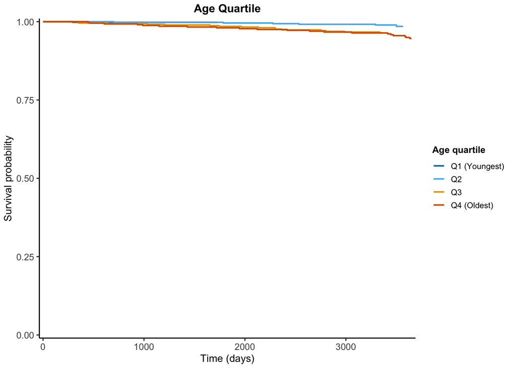

```
## Saved: KM_stroke_panel.pdf  &  KM_stroke_panel.png
```

```
## Start:  AIC=662.26
## Surv(time_obs, stroke_10yr) ~ AGE + SYSBP + DIABETES + BPMEDS +
##     PREVCHD + CURSMOKE + TOTCHOL + BMI
##
##            Df    AIC
## - PREVCHD   1 660.27
## - BMI       1 660.28
## - TOTCHOL   1 660.51
## - BPMEDS    1 661.64
## <none>        662.26
## - CURSMOKE  1 664.95
##
## Step:  AIC=660.27
## Surv(time_obs, stroke_10yr) ~ AGE + SYSBP + DIABETES + BPMEDS +
##     CURSMOKE + TOTCHOL + BMI
##
##            Df    AIC
## - BMI       1 658.29
## - TOTCHOL   1 658.53
## - BPMEDS    1 659.67
## <none>        660.27
## - CURSMOKE  1 662.95
##
## Step:  AIC=658.29
## Surv(time_obs, stroke_10yr) ~ AGE + SYSBP + DIABETES + BPMEDS +
##     CURSMOKE + TOTCHOL
##
##            Df    AIC
## - TOTCHOL   1 656.54
## - BPMEDS    1 657.68
## <none>        658.29
## - CURSMOKE  1 661.21
##
## Step:  AIC=656.54
## Surv(time_obs, stroke_10yr) ~ AGE + SYSBP + DIABETES + BPMEDS +
##     CURSMOKE
##
##            Df    AIC
## - BPMEDS    1 655.97
## <none>        656.54
```

[output cut: 44 more lines]

```
##
##            Df    AIC
## - PREVCHD   1 808.74
## - CURSMOKE  1 809.07
## <none>        809.43
##
## Step:  AIC=808.74
## Surv(time_obs, stroke_10yr) ~ AGE + SYSBP + DIABETES + CURSMOKE
##
##            Df    AIC
## - CURSMOKE  1 808.28
## <none>        808.74
##
## Step:  AIC=808.28
## Surv(time_obs, stroke_10yr) ~ AGE + SYSBP + DIABETES
```

[figure not shown]

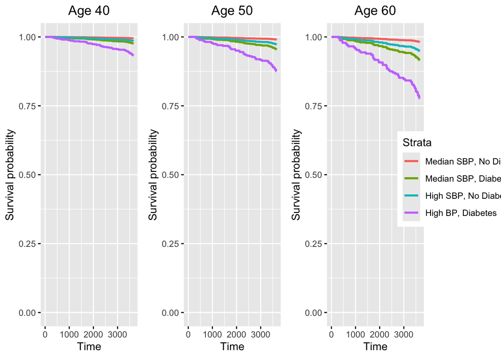

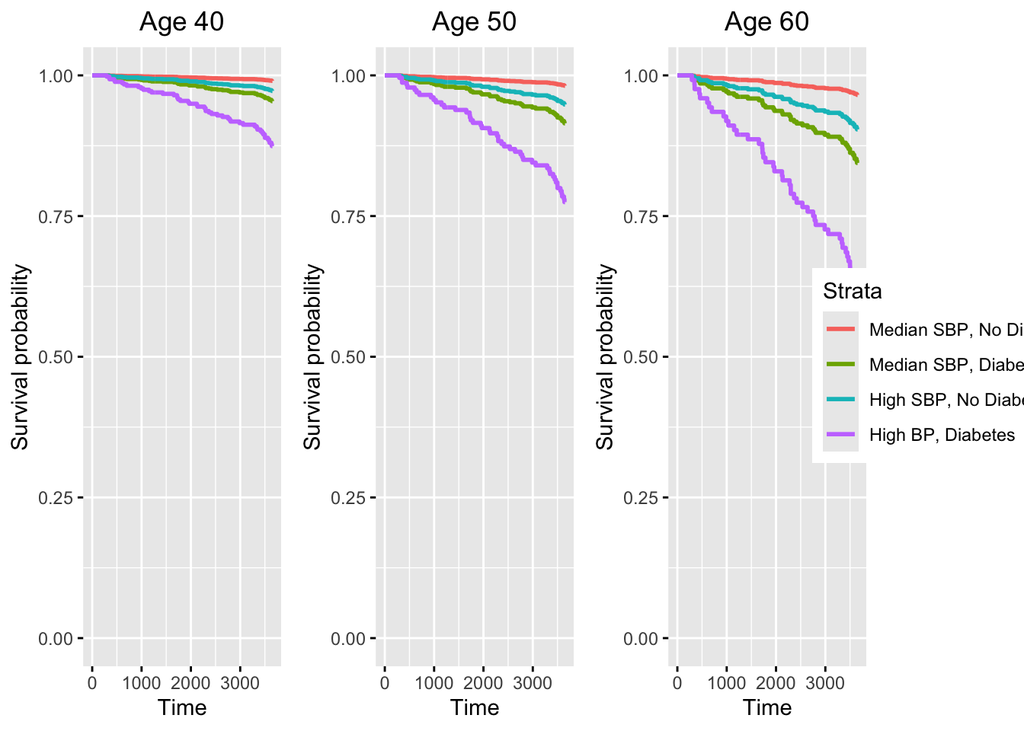

Framingham study

Data description

Hypotheses

statistical hypotheses

difference over time periods

*Methods*

**table 1.**

Data comes from a subset of the Framingham Heart Study, with 4,434 individuals followed for 3 time periods, approximately 6 years apart, ranging from 1956 to 1968. For the risk factor analysis, we excluded individuals who had already had a stroke before the beginnng of the study (TIMESTRK=0), only considered period 1, in order to capture baseline characteristics, and censored all individuals at 10 years (3652 days), resulting in 4,402 remaining individuals. We disregarded other events measured in the data. We also considered complete case analysis, removing individuals with missing information on the covariates we are interested in, and stratified the data into a male group and female group, with final sample sizes of 1,897 and 2,378 respectively. To analyze change in risk factors, we used data on the same individuals for periods 1 and 3 for consistent interpretation.

```r
table1_m <- framdat_m |>
  tbl_summary(
    include = c(TOTCHOL, AGE, SYSBP, DIABP, CURSMOKE, CIGPDAY, BMI, DIABETES, BPMEDS, HEARTRTE,
                GLUCOSE, educ, PREVCHD, PREVAP, PREVMI,  PREVHYP, STROKE, HYPERTEN, time_obs
    ), # Specify variables to include (optional)
    missing = "ifany"                      # Display missing values if any exist
  )

table1_f <- framdat_f |>
  tbl_summary(
    include = c(TOTCHOL, AGE, SYSBP, DIABP, CURSMOKE, CIGPDAY, BMI, DIABETES, BPMEDS, HEARTRTE,
                GLUCOSE, educ, PREVCHD, PREVAP, PREVMI,  PREVHYP, STROKE, HYPERTEN, time_obs
    ), # Specify variables to include (optional)
    missing = "ifany"                      # Display missing values if any exist
  )

tbl_merge(
  tbls = list(table1_m, table1_f),
  tab_spanner = c("**Male**", "**Female**")
)
```

[output not shown]

| **Characteristic** | **Male** **N = 1,897**<sup>1</sup> | **Female** **N = 2,378**<sup>1</sup> |
| --- | --- | --- |
| TOTCHOL | 231 (206, 259) | 237 (206, 268) |
| AGE | 49 (42, 57) | 49 (43, 57) |
| SYSBP | 129 (118, 141) | 129 (116, 146) |
| DIABP | 82 (76, 90) | 81 (74, 89) |
| CURSMOKE | 1,147 (60%) | 958 (40%) |
| CIGPDAY | 11 (0, 20) | 0 (0, 10) |
| Unknown | 15 | 15 |
| BMI | 26.1 (24.0, 28.3) | 24.8 (22.5, 27.8) |
| DIABETES | 56 (3.0%) | 57 (2.4%) |
| BPMEDS | 40 (2.1%) | 92 (3.9%) |
| HEARTRTE | 75 (66, 80) | 75 (69, 85) |
| Unknown | 1 |  |
| GLUCOSE | 78 (71, 87) | 78 (72, 86) |
| Unknown | 114 | 234 |
| educ |  |  |
| 1 | 821 (45%) | 925 (40%) |
| 2 | 501 (27%) | 736 (32%) |
| 3 | 232 (13%) | 461 (20%) |
| 4 | 288 (16%) | 200 (8.6%) |
| Unknown | 55 | 56 |
| PREVCHD | 113 (6.0%) | 64 (2.7%) |
| PREVAP | 86 (4.5%) | 52 (2.2%) |
| PREVMI | 65 (3.4%) | 14 (0.6%) |
| PREVHYP | 607 (32%) | 750 (32%) |
| STROKE | 176 (9.3%) | 197 (8.3%) |
| HYPERTEN | 1,368 (72%) | 1,758 (74%) |
| time_obs | 3,653 (3,653, 3,653) | 3,653 (3,653, 3,653) |

<sup>1</sup> Median (Q1, Q3); n (%)

For both sex groups, and for ages 40,50, and 60, we were primarily interested in the stroke risk for the following profiles: someone with diabetes, someone with high blood pressure (we used 160 to compute our risk profiles), and someone with both. Additionally, because smoking was found to be predictive, we also considered the risk profile of a smoker, as well as a smoker with diabetes and high blood pressure.

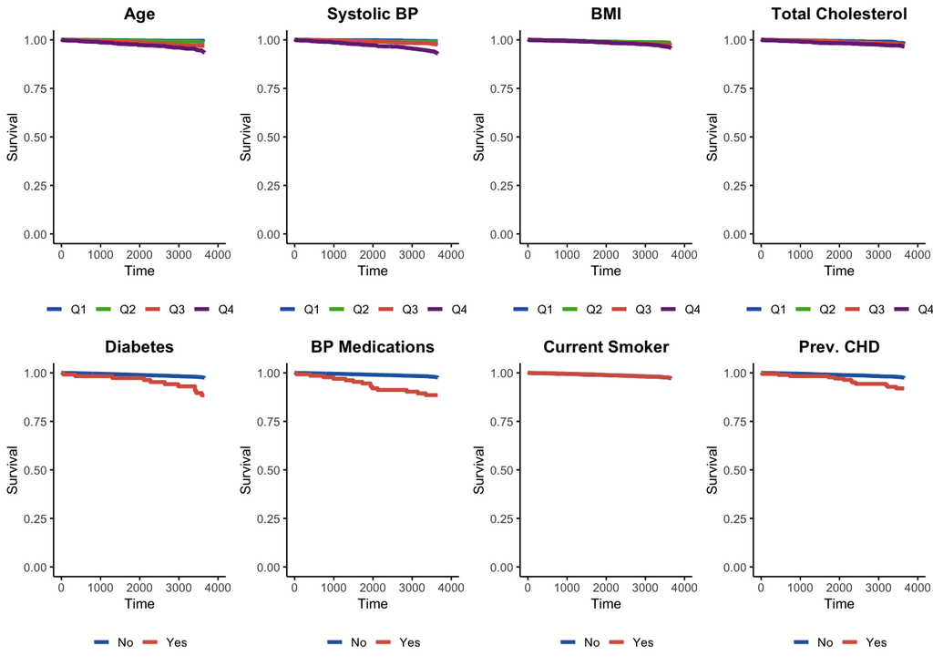

```r
library(survival)
library(survminer)
library(dplyr)
library(ggplot2)
library(gridExtra)
# --- Helper: create quantile groups for continuous variables ---
quartile_group <- function(x) {
  cut(x,
      breaks = quantile(x, probs = 0:4/4, na.rm = TRUE),
      labels = c("Q1","Q2","Q3","Q4"),
      include.lowest = TRUE)
}

# --- Prepare grouping variables ---
framdat2 <- framdat %>%
  mutate(
    AGE_Q      = quartile_group(AGE),
    SYSBP_Q    = quartile_group(SYSBP),
    BMI_Q      = quartile_group(BMI),
    TOTCHOL_Q  = quartile_group(TOTCHOL),
    DIABETES   = factor(DIABETES,   labels = c("No","Yes")),
    BPMEDS     = factor(BPMEDS,     labels = c("No","Yes")),
    CURSMOKE   = factor(CURSMOKE,   labels = c("No","Yes")),
    PREVCHD    = factor(PREVCHD,    labels = c("No","Yes"))
  )

# --- Fit KM models ---
# Adjust 'TIME' and 'EVENT' to your actual survival time and status columns
fits <- list(
  AGE     = survfit(Surv(time_obs, stroke_10yr) ~ AGE_Q,     data = framdat2),
  SYSBP   = survfit(Surv(time_obs, stroke_10yr) ~ SYSBP_Q,   data = framdat2),
  BMI     = survfit(Surv(time_obs, stroke_10yr) ~ BMI_Q,     data = framdat2),
  TOTCHOL = survfit(Surv(time_obs, stroke_10yr) ~ TOTCHOL_Q, data = framdat2),
  DIABETES = survfit(Surv(time_obs,stroke_10yr) ~ DIABETES,  data = framdat2),
  BPMEDS  = survfit(Surv(time_obs, stroke_10yr) ~ BPMEDS,    data = framdat2),
  CURSMOKE = survfit(Surv(time_obs, stroke_10yr) ~ CURSMOKE,  data = framdat2),
  PREVCHD = survfit(Surv(time_obs, stroke_10yr) ~ PREVCHD,   data = framdat2)
)

# --- Plot settings ---
palette_q4  <- c("#2166AC","#4DAC26","#D6604D","#762A83")  # 4-level continuous
palette_bin <- c("#2166AC","#D6604D")                       # binary

common_opts <- list(
  conf.int    = FALSE,
  risk.table  = FALSE,
  ggtheme     = theme_classic(base_size = 8),
  legend.labs = NULL,   # overridden per plot
  font.main   = c(9, "bold"),
  font.x      = 8,
  font.y      = 8,
  font.legend = 7,
  legend      = "bottom",
  xlab        = "Time",
  ylab        = "Survival"
)

make_plot <- function(fit, title, labs, pal) {
  ggsurvplot(
    fit,
    data        = framdat2,
    conf.int    = FALSE,
    censor=FALSE,
    risk.table  = FALSE,
    palette     = pal,
    legend.labs = labs,
    legend      = "bottom",
    title       = title,
    xlab        = "Time",
    ylab        = "Survival",
    ggtheme     = theme_classic(base_size = 8) +
      theme(
        plot.title      = element_text(size = 9, face = "bold", hjust = 0.5),
        legend.key.size = unit(0.35, "cm"),
        legend.text     = element_text(size = 6.5),
        legend.title    = element_blank(),
        axis.title      = element_text(size = 7.5)
      )
  )$plot
}

plots <- list(
  make_plot(fits$AGE,      "Age",                   c("Q1","Q2","Q3","Q4"), palette_q4),
  make_plot(fits$SYSBP,    "Systolic BP",           c("Q1","Q2","Q3","Q4"), palette_q4),
  make_plot(fits$BMI,      "BMI",                   c("Q1","Q2","Q3","Q4"), palette_q4),
  make_plot(fits$TOTCHOL,  "Total Cholesterol",     c("Q1","Q2","Q3","Q4"), palette_q4),
  make_plot(fits$DIABETES, "Diabetes",              c("No","Yes"),          palette_bin),
  make_plot(fits$BPMEDS,   "BP Medications",        c("No","Yes"),          palette_bin),
  make_plot(fits$CURSMOKE, "Current Smoker",        c("No","Yes"),          palette_bin),
  make_plot(fits$PREVCHD,  "Prev. CHD",             c("No","Yes"),          palette_bin)
)

# --- Combine into 2x4 grid ---
km_grid <- gridExtra::grid.arrange(
  grobs  = plots,
  ncol   = 4,
  nrow   = 2
)
```

mention missingness and outliers

how did you handle other events?

backwards-AIC using investigator provided variables

computed hazard ratios, probabilities

how is high BP defined?

why did you pick smoking and smoking + other factors

descriptive analysis of change in variables over time

*results*

interpret / report hazard rations and probabilities

coxph curves

how would change in variables over time effect analysis

*Discusiion*

overview of result findings

clinical significance

table 1 kaplan meier cox men cox women probabilities table change table